## Agenda

Recordeu, teniu els materials de classe a: http://vicpena.github.io/doe

- Dijous 20: Lab de dissenys fraccionals
- Dimarts 25: Resolem examen de prova junts
- Dijous 27: Examen parcial

A partir de la setmana vinent, tindreu l’Isaac

Avui farem:

- Dissenys complets $2^k$ : Exemple cardigan
- Dissenys fraccionals $2^{k-p}$ : Exemple galetes i exemple tub d’escapament

## Exemple: Cardigan

La part davantera d’un jersei cordat està formada per 2 meitats, i cadascuna d’elles està formada al seu torn pel que anomenem cos i tira. La tira és la zona on van allotjats els botons o els traus (segons el costat) i està teixida de manera que és més forta i consistent que el cos.

Tradicionalment, el cos i la tira es teixien per separat i després es cosien, però en l’actualitat hi ha màquines que teixeixen simultàniament, en una mateixa peça, el cos i la tira, amb l’avantatge que s’eliminen operacions en la confecció de la peça.

L’inconvenient és que en tenir la tira diferent tipus de punt, i estar teixida sota altres paràmetres, de vegades resulta ser més llarga o més curta que el cos, de manera que la peça resulta defectuosa.

Per determinar les condicions de teixit de la tira que aconsegueixen que la longitud del cos (LC) i de la tira (LT) siguin iguals, es realitza un disseny $2^3$ amb els següents factors:

- A: Tipus de tira: Interlock (–) i tubular (+)
- B: Número d'agulles: 4 i 10
- C: Graduació del punto (longitud de la malla a la part interior): 9,0 i 10,8

S'obtenen els següents resultats, en l'ordre estàndard de la matriu de disseny:

```r
lc = c(67.8, 71.7, 67.6, 77.0, 62.2, 71.6, 71.7, 75.6)
lt = c(62.6, 66.8, 62.6, 71.7, 61.1, 66.8, 70.6, 70.6)
```

Temps que es triga en fer la peça (t, mm:ss): 9:18 9:18 9:17 9:18 12:40 12:39 12:39 12:39

1. Expliqueu com influeixen cadascun dels factors en el temps que triga a teixir-se la peça

**Solució:** Convertim els temps a segons

```r
temps = c(9*60+18, 9*60+18, 9*60+17, 9*60+18,
          12*60+40, 12*60+39, 12*60+39, 12*60+39)
```

És un disseny $2^3$. Creem la matriu de disseny amb `FrF2` , afegim la resposta, i fem el Daniel plot. L’únic efecte important és el de la graduació: el procés és molt més lent quan la graduació és “gran”.

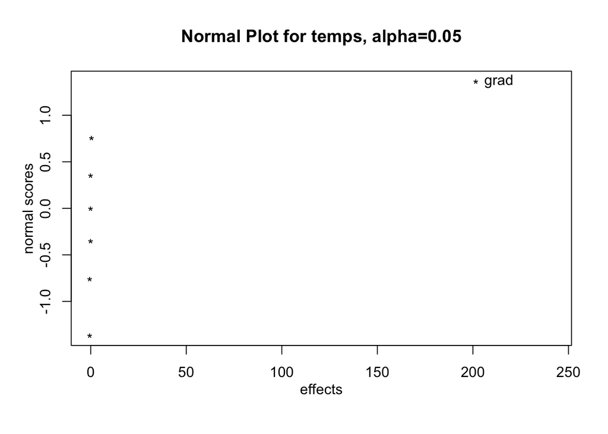

```r
library(FrF2)
disseny = FrF2(nruns = 8, nfactors = 3,
               factor.names = c("tipus", "agulla", "grad"),
               randomize = FALSE)
dis_temps = add.response(disseny, temps)
DanielPlot(dis_temps)
```

2. Tenint en compte que l’objectiu és que LC = LT (no importa el valor concret que prenguin), indiqueu quina penseu que ha de ser la resposta a analitzar

**Solució:** La diferència LC-LT és una bona opció.

```r
dif = lc-lt
```

3. Identifiqueu els efectes importants i expliqueu com influeixen els factors en la resposta.

**Solució:** Creem el disseny amb `dif` com a resposta i mirem el Daniel plot. Identifiquem el tipus, la graduació i la seva interacció com a importants.

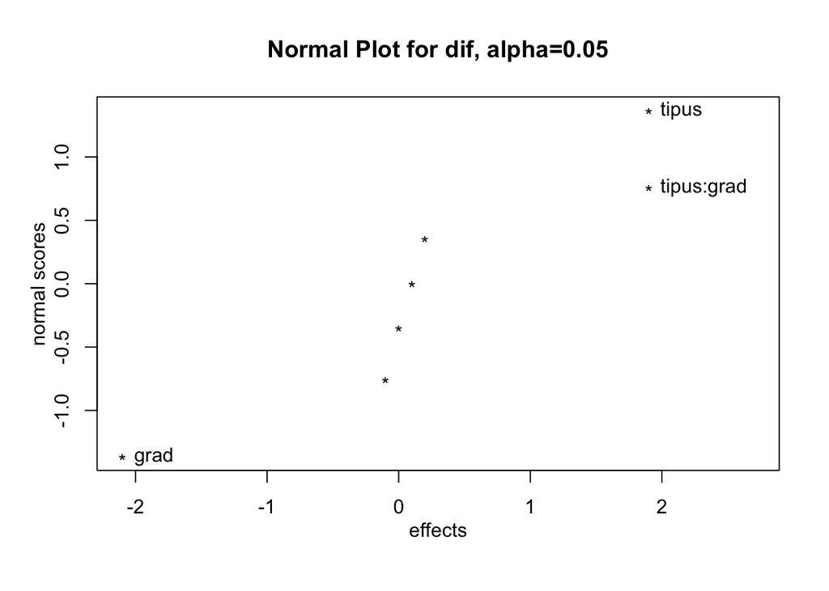

```r
dis_dif = add.response(disseny, dif)
DanielPlot(dis_dif)
```

Fem la taula ANOVA i veiem que tot és significatiu.

```r
mod_dif = aov(dif ~ tipus + tipus*grad + grad, dis_dif)
summary(mod_dif)
```

```
##             Df Sum Sq Mean Sq F value   Pr(>F)
## tipus        1   7.22    7.22   240.7 0.000101 ***
## grad         1   8.82    8.82   294.0 6.79e-05 ***
## tipus:grad   1   7.22    7.22   240.7 0.000101 ***
## Residuals    4   0.12    0.03
## ---
## Signif. codes:  0 '***' 0.001 '**' 0.01 '*' 0.05 '.' 0.1 ' ' 1
```

Mirem el gràfic d’efectes i la taula d’efectes estimats

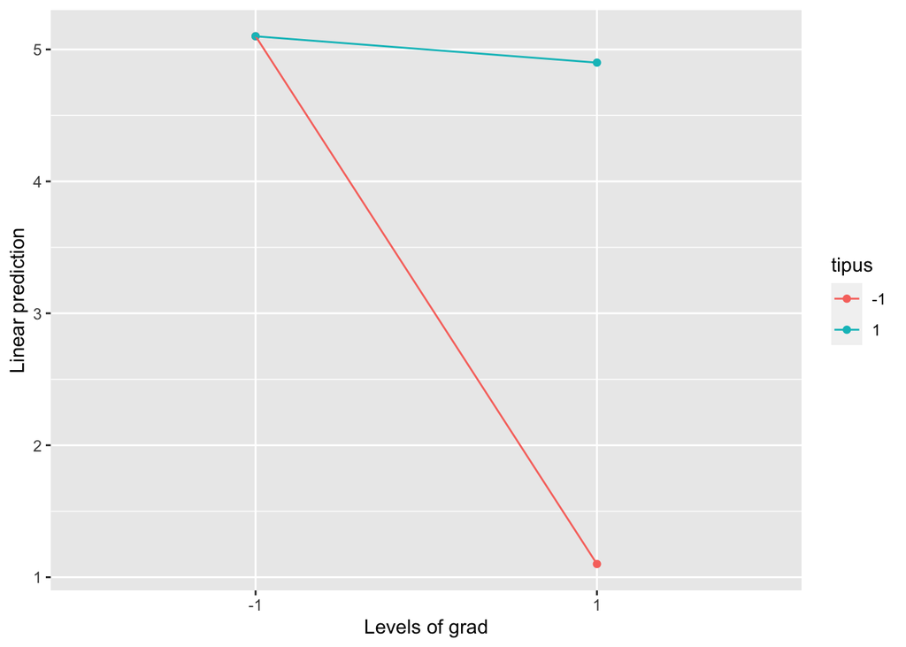

```r
library(emmeans)
emmip(mod_dif, tipus ~ grad)
```

```r
emmeans(mod_dif, ~ grad*tipus)
```

```
##  grad tipus emmean    SE df lower.CL upper.CL
##  -1   -1       5.1 0.122  4     4.76     5.44
##  1    -1       1.1 0.122  4     0.76     1.44
##  -1   1        5.1 0.122  4     4.76     5.44
##  1    1        4.9 0.122  4     4.56     5.24
##
## Confidence level used: 0.95
```

Hi ha una clara interacció. L’efecte de la graduació depèn clarament del tipus.

4. En cas que poguéssiu continuar l’experimentació, indiqueu com ho faríeu.

**Solució:** Donat que la graduació és una variable numèrica, intentaria seguir pujant el seu valor per veure si trobem una diferència de 0. Fixaríem el tipus a “Interlock”.

5. Es pot aconseguir l’objectiu que LC = LT? És possible aconseguir-ho amb un temps de teixit inferior a 10 minuts? Raoneu la resposta.

**Solució:** No ho podem saber segur… Res no ens garanteix que, si seguim pujant la graduació, la diferència baixarà fins a 0. Donat l’efecte de la graduació sobre la resposta descrit a la primera part, sembla poc probable que trobem LT = LC amb un temps de teixit inferior a 10 minuts.

## Exemple: Galetes

**Variable resposta:** com de bones són les galetes, en una escala de 0 a 10

**Factors:**

- Mantega: 10g o 15g
- Sucre: mitja tassa o una tassa sencera
- Llevat: mitja cullerada o una sencera
- Temps de cocció: 12min o 16min

4 factors, però només s’han fet 8 experiments: disseny $2^{4-1}$

Primer, creem la matriu de disseny amb `FrF2`:

```r
design = FrF2(nruns = 8, nfactors = 4,
              factor.names = c("mantega", "sucre", "llevat", "temps"),
              randomize = FALSE)

aliasprint(design)
```

```
## $legend
## [1] A=mantega B=sucre   C=llevat  D=temps
##
## $main
## character(0)
##
## $fi2
## [1] AB=CD AC=BD AD=BC
```

És un disseny de resolució IV: hi ha interaccions de dos factors que estan confoses entre elles

Afegim la resposta

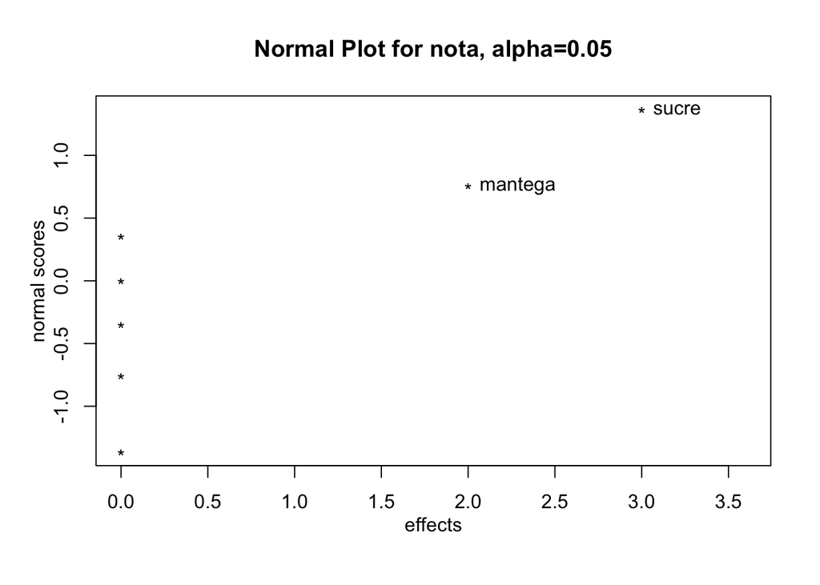

```r
nota =  c(2, 4, 5, 7, 2, 4, 5, 7)
design = add.response(design, nota)
DanielPlot(design)
```

Sembla que l’efecte del sucre i la mantega són importants. No hi ha interaccions que destaquin al gràfic.

Ajustem el model amb mantega i sucre:

```r
mod = aov(nota ~ sucre + mantega, design)
summary(mod)
```

```
##             Df Sum Sq Mean Sq   F value Pr(>F)
## sucre        1     18      18 1.678e+31 <2e-16 ***
## mantega      1      8       8 7.456e+30 <2e-16 ***
## Residuals    5      0       0
## ---
## Signif. codes:  0 '***' 0.001 '**' 0.01 '*' 0.05 '.' 0.1 ' ' 1
```

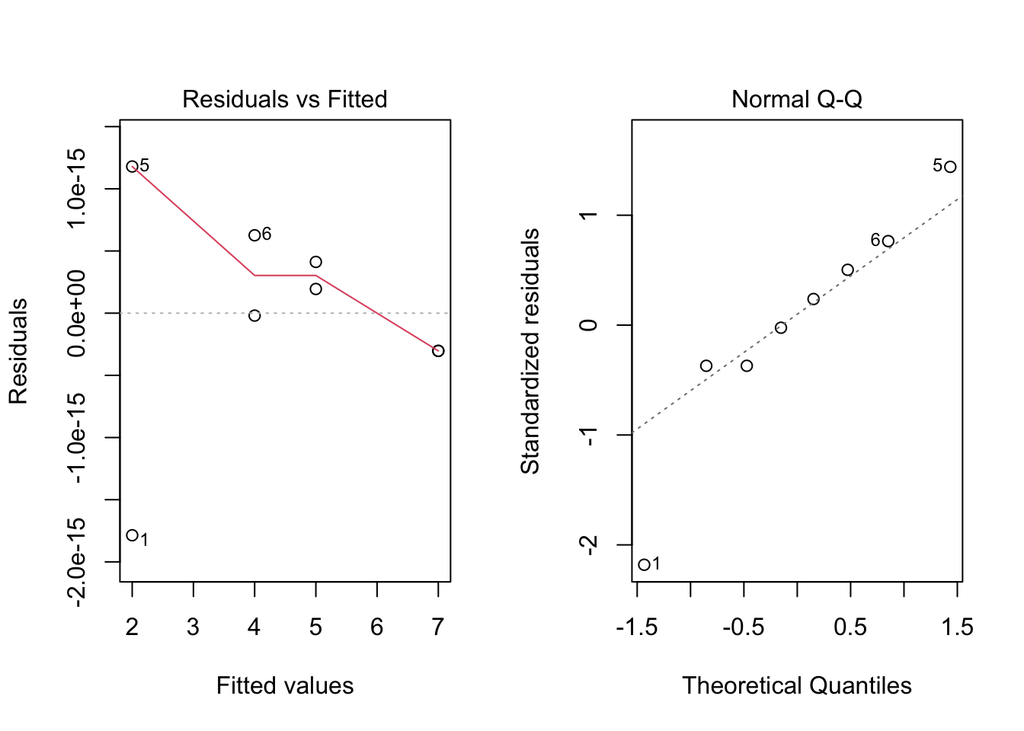

```r
par(mfrow = c(1,2))
plot(mod, 1:2)
```

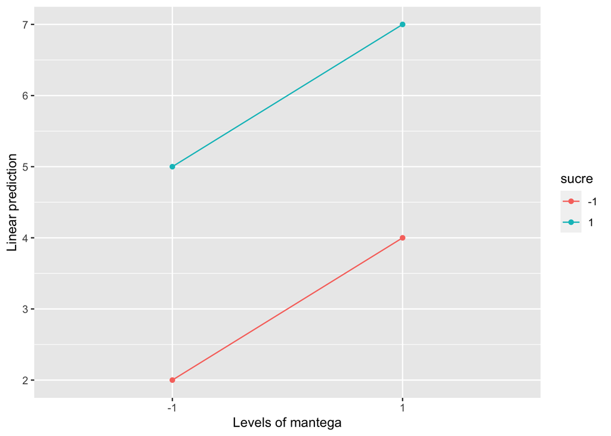

```r
emmip(mod, sucre ~ mantega)
```

```r
emmeans(mod, ~ sucre + mantega)
```

```
##  sucre mantega emmean       SE df lower.CL upper.CL
##  -1    -1           2 6.34e-16  5        2        2
##  1     -1           5 6.34e-16  5        5        5
##  -1    1            4 6.34e-16  5        4        4
##  1     1            7 6.34e-16  5        7        7
##
## Confidence level used: 0.95
```

Sembla que com més mantega i sucre, millor. Podríem continuar investigant afegint més sucre i mantega.

## Exemple: Tub d’escapament

7 factors poden influir el diàmetre d’un tub d’escapament.

L’empresa només pot fer 8 experiments per raons de pressupost.

Van fer un disseny $2^{7-4}$.

Creem la matriu de disseny i afegim la resposta

```r
design = FrF2(nruns = 8, nfactors = 7, randomize = FALSE)
y = c(34.6, 46.3, 48.6, 44.9, 49.7, 34.0, 46.5, 49.0)
design = add.response(design, y)
```

Mirem els patrons de confusió

```r
aliasprint(design)
```

```
## $legend
## [1] A=A B=B C=C D=D E=E F=F G=G
##
## $main
## [1] A=BD=CE=FG B=AD=CF=EG C=AE=BF=DG D=AB=CG=EF E=AC=BG=DF F=AG=BC=DE G=AF=BE=CD
##
## $fi2
## character(0)
```

És un disseny de resolució III: hi ha efectes principals confosos amb interaccions de 2 variables.

Fem el Daniel plot

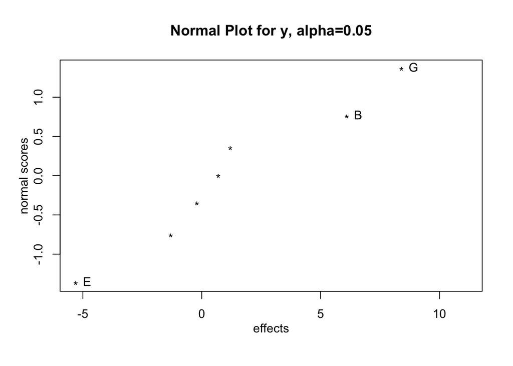

```r
DanielPlot(design)
```

B, E i G estan marcades com a variables importants.

- B està confosa amb AD, CF, i EG
- E està confosa amb AC, BG, i DF
- G està confosa amb AF, BE, i CD

Què fem?

Conclusió: sembla que els factors B, E i G són els més importants. Seria bo fer un disseny complet $2^3$ amb aquests factors i veure què passa.